# Introduction to ggplot2

17-3-7

## ggplot2 part of tidyverse

```r
library(ggplot2)
```

or

```r
library(tidyverse)
```

## Other alternatives

- R base
- **grid**
- **lattice**.

## Grammar of graphics

**ggplot2** a [grammar of graphics](http://www.springer.com/us/book/9780387245447),

- Construct hundreds of different sentences by learning just a handful of verbs, nouns and adjectives without having to memorize each specific sentence.

## Strength and limitation

- **ggplot2** is easier for beginners is that its default behavior is carefully chosen to satisfy the great majority of cases and is visually pleasing.
- One limitation is that **ggplot2** is designed to work exclusively with data tables in which rows are observations and columns are variables.

## Sheet cheats

- You should have the [ggplot2 sheet cheat](https://www.rstudio.com/wp-content/uploads/2015/03/ggplot2-cheatsheet.pdf) handy.
- To find perform an internet search for "ggplot2 cheat sheet".

## The components of a graph

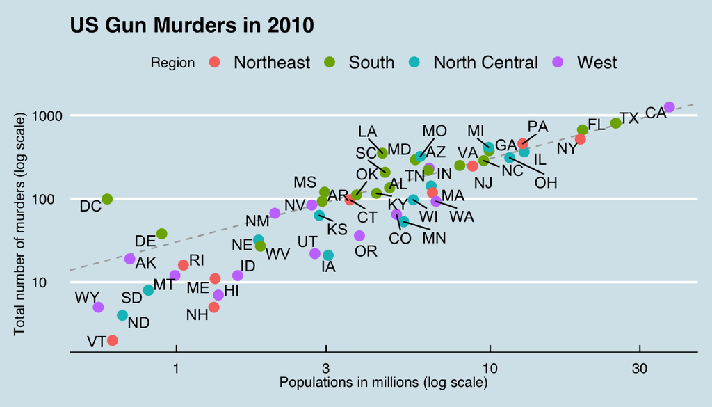

## Other minor components

- The points are labeled with the state abbreviations.
- The range of the x-axis and y-axis appears to be defined by the range of the data. They are both on log-scales.
- There are labels, a title, a legend, and we use the style of The Economist magazine.

## Load data

```r
library(dslabs)
data(murders)
```

## `ggplot` objects

```r
ggplot(data = murders)
```

## `ggplot` objects

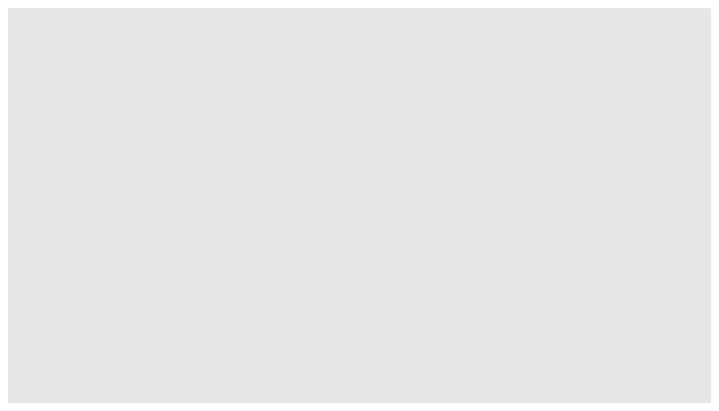

```r
murders %>% ggplot()
```

## `ggplot` objects

```r
p <- ggplot(data = murders)
class(p)
```

```
## [1] "gg"     "ggplot"
```

## Rendering a plot

```r
print(p)
p
```

## Geometries

> > DATA %>% `ggplot()` + LAYER 1 + LAYER 2 + … + LAYER N

## Geometries

- Geometry function names follow the pattern: `geom_X`
- where X is the name of the geometry.
- Examples include `geom_point`, `geom_bar` and `geom_histogram`.

## Aesthetics for geometries

- Look at help file. Here is `geom_point`

```
> Aesthetics
>
> geom_point understands the following aesthetics (required aesthetics are in bold):
>
> x
>
> y
>
> alpha
>
> colour
```

## Aesthetic mappings

```r
murders %>% ggplot() +
  geom_point(aes(x = population/10^6, y = total))
```

- We can drop the `x =` and `y =` if we wanted to since these are the first and second expected arguments, as seen in the help page.

## We can add to an existing plot object

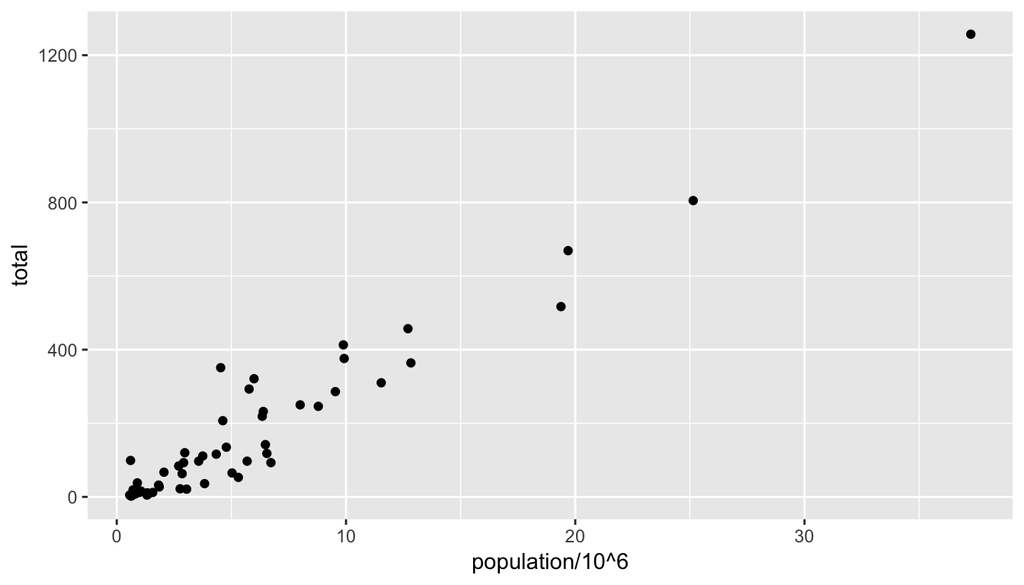

```r
p + geom_point(aes(population/10^6, total))
```

## Layers

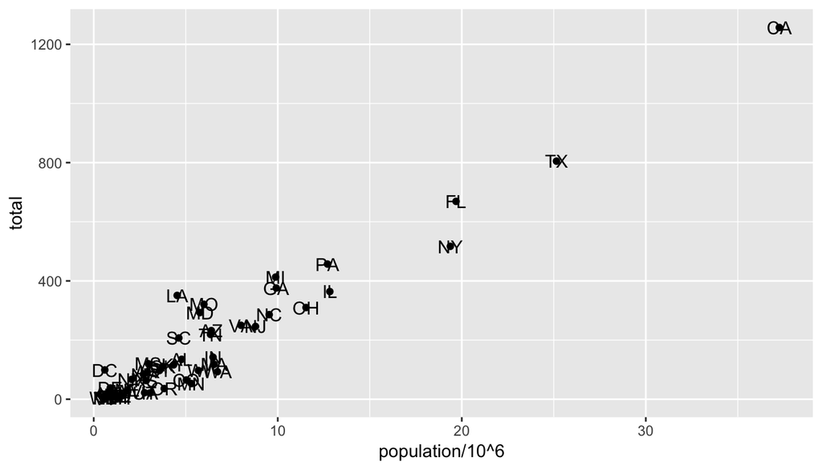

```r
p + geom_point(aes(population/10^6, total)) +
  geom_text(aes(population/10^6, total, label = abb))
```

## Where are variabled defined?

This is fine:

```r
p_test <- p + geom_text(aes(population/10^6, total, label = abb))
```

## Where are variabled defined?

This is not:

```r
p_test <- p + geom_text(aes(population/10^6, total), label = abb)
```

## Tinkering with arguments

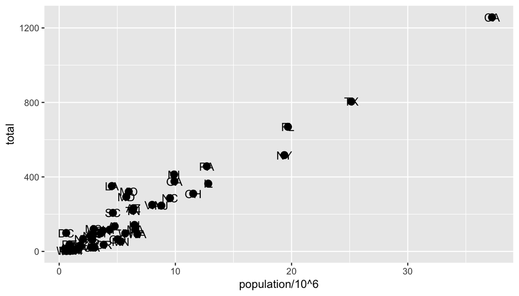

```r
p + geom_point(aes(population/10^6, total), size = 3) +
  geom_text(aes(population/10^6, total, label = abb))
```

## Tinkering with arguments

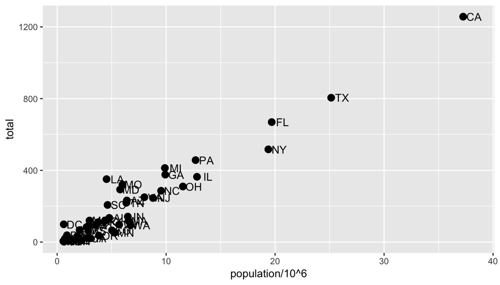

```r
p + geom_point(aes(population/10^6, total), size = 3) +
  geom_text(aes(population/10^6, total, label = abb), nudge_x = 1)
```

## Global versus local aesthetic mappings

```r
args(ggplot)
```

```
## function (data = NULL, mapping = aes(), ..., environment = parent.frame())
## NULL
```

## Global versus local aesthetic mappings

```r
p <- murders %>% ggplot(aes(population/10^6, total, label = abb))
```

## Global versus local aesthetic mappings

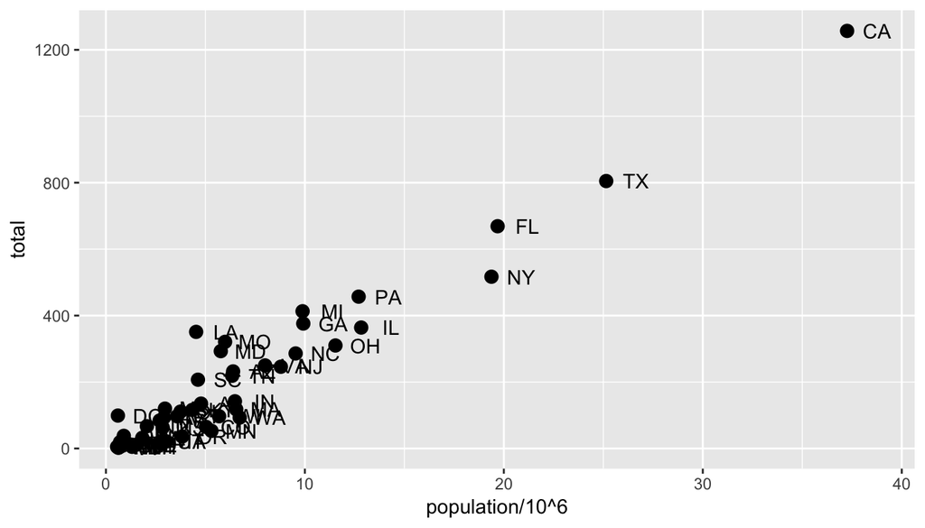

```r
p + geom_point(size = 3) +
  geom_text(nudge_x = 1.5)
```

## Global versus local aesthetic mappings

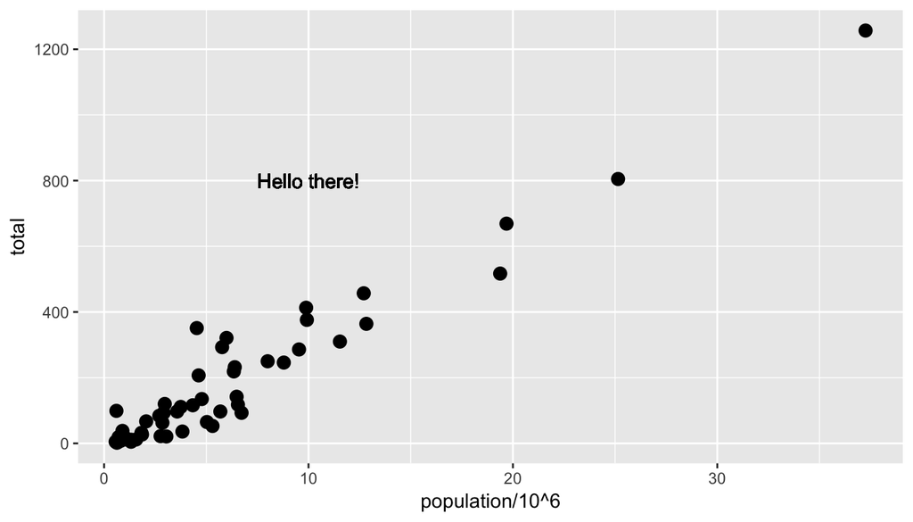

```r
p + geom_point(size = 3) +
  geom_text(aes(x = 10, y = 800, label = "Hello there!"))
```

## Scales

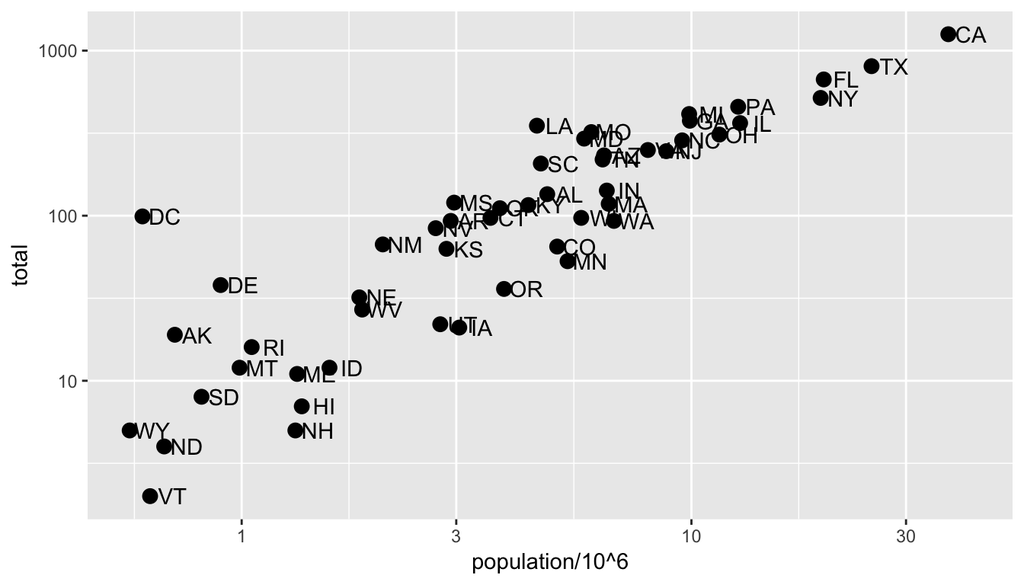

```r
p + geom_point(size = 3) + geom_text(nudge_x = 0.05) +
  scale_x_continuous(trans = "log10") +
  scale_y_continuous(trans = "log10")
```

## Scales

```r
p + geom_point(size = 3) +
  geom_text(nudge_x = 0.05) +
  scale_x_log10() +
  scale_y_log10()
```

## Labels and titles

```r
p + geom_point(size = 3) +
  geom_text(nudge_x = 0.05) +
  scale_x_log10() +
  scale_y_log10() +
  xlab("Populations in millions (log scale)") +
  ylab("Total number of murders (log scale)") +
  ggtitle("US Gun Murders in 2010")
```

## Labels and titles

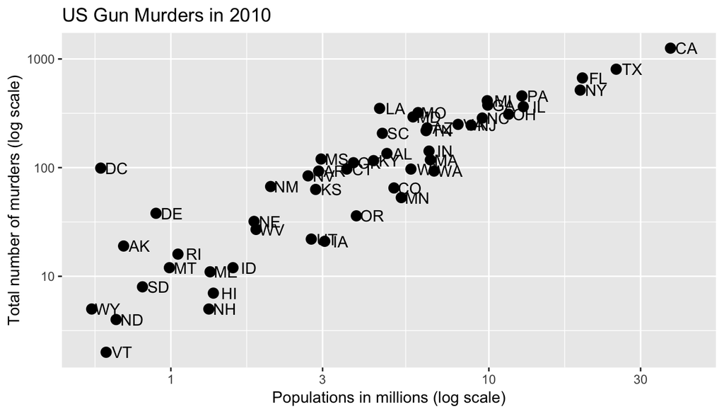

## Categories as colors

```r
p <-  murders %>% ggplot(aes(population/10^6, total, label = abb)) +
  geom_text(nudge_x = 0.05) +
  scale_x_log10() +
  scale_y_log10() +
  xlab("Populations in millions (log scale)") +
  ylab("Total number of murders (log scale)") +
  ggtitle("US Gun Murders in 2010")
```

## Categories as colors

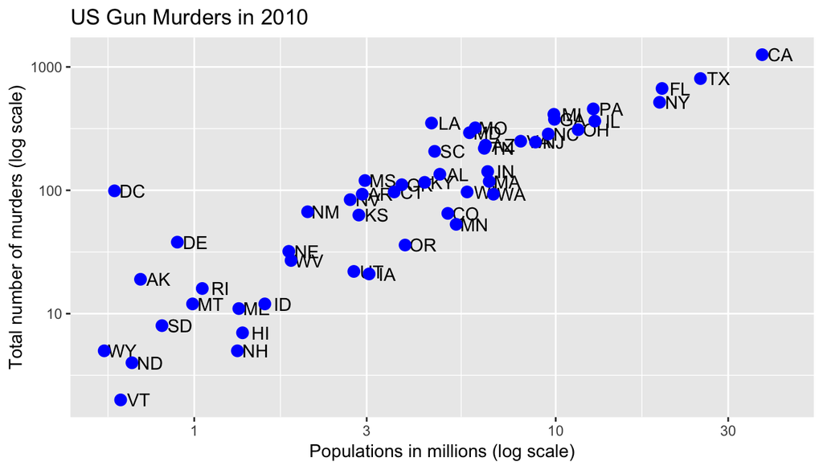

```r
p + geom_point(size = 3, color ="blue")
```

## Example: color as a mapping

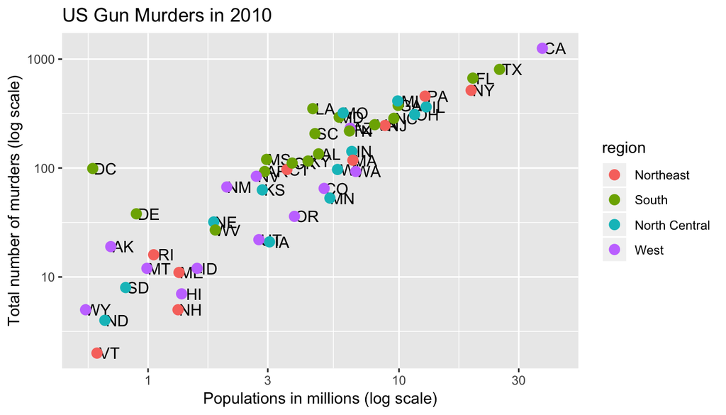

```r
p + geom_point(aes(col=region), size = 3)
```

## Annotation, shapes, and adjustments

```r
r <- murders %>%
  summarize(rate = sum(total) /  sum(population) * 10^6) %>%
  pull(rate)
```

## Annotation, shapes, and adjustments

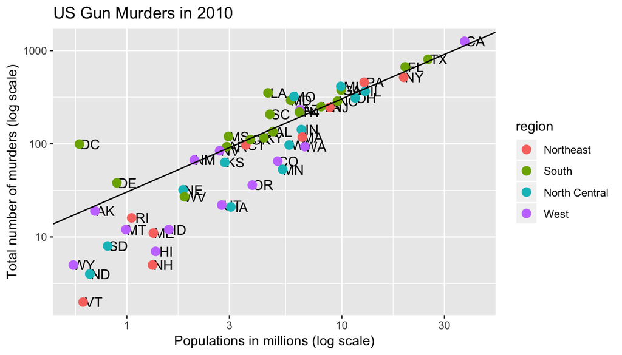

```r
p + geom_point(aes(col=region), size = 3) +
  geom_abline(intercept = log10(r))
```

## Annotation, shapes, and adjustments

```r
p <- p + geom_abline(intercept = log10(r), lty = 2, color = "darkgrey") +
  geom_point(aes(col=region), size = 3)
```

## Annotation, shapes, and adjustments

```r
p <- p + scale_color_discrete(name = "Region")
```

## Add-on packages

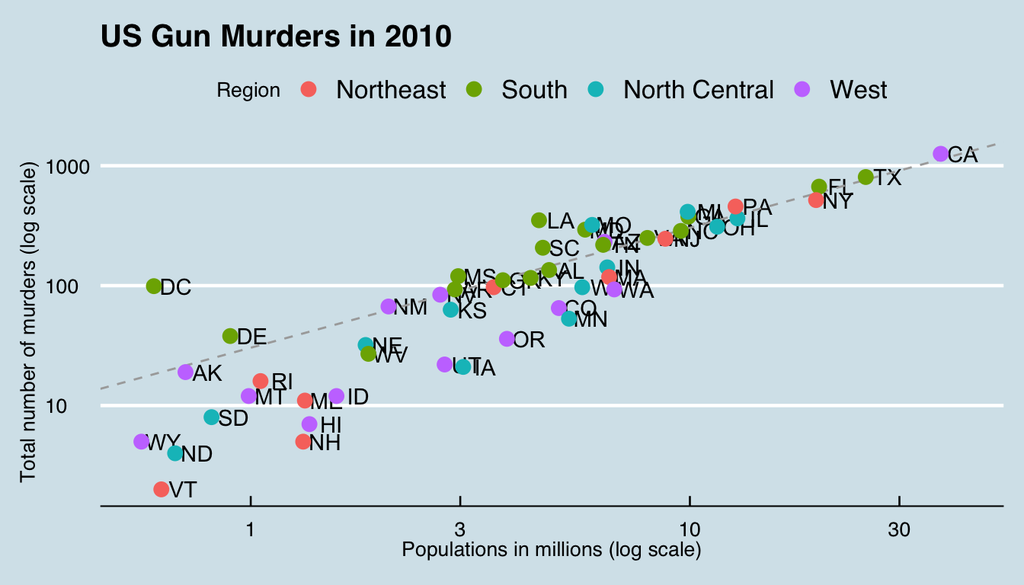

```r
library(ggthemes)
p + theme_economist()
```

## Another example

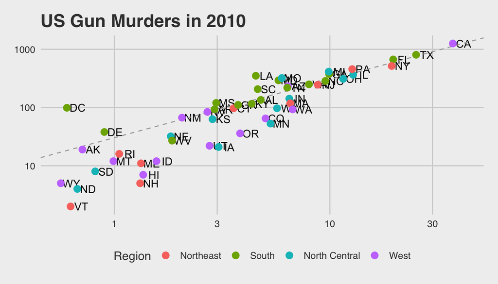

```r
library(ggthemes)
p + theme_fivethirtyeight()
```

## Putting it all together

```r
r <- murders %>%
  summarize(rate = sum(total) /  sum(population) * 10^6) %>%
  pull(rate)

murders %>% ggplot(aes(population/10^6, total, label = abb)) +
  geom_abline(intercept = log10(r), lty = 2, color = "darkgrey") +
  geom_point(aes(col=region), size = 3) +
  geom_text_repel() +
  scale_x_log10() +
  scale_y_log10() +
  xlab("Populations in millions (log scale)") +
  ylab("Total number of murders (log scale)") +
  ggtitle("US Gun Murders in 2010") +
  scale_color_discrete(name = "Region") +
  theme_economist()
```

## Putting it all together

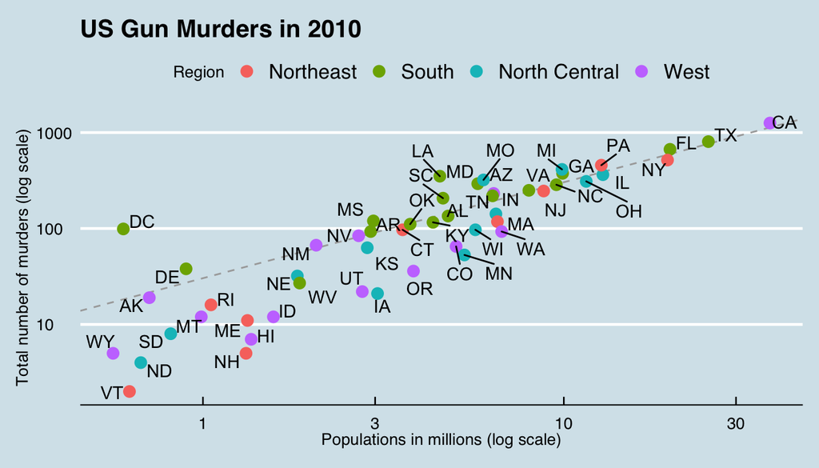

## Quick plots with `qplot`

Make a quick scatterplot:

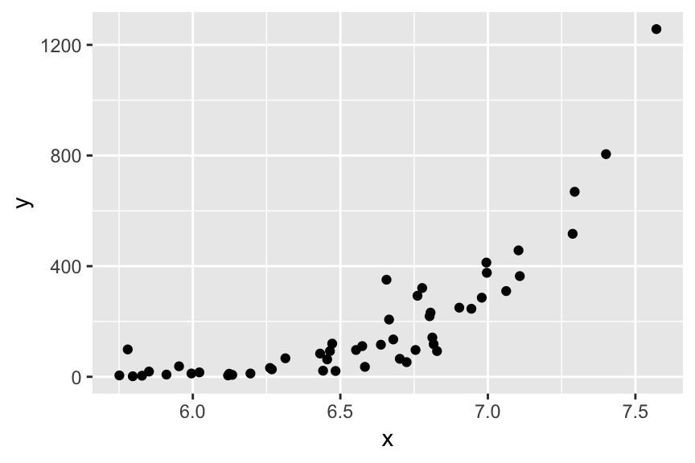

```r
data(murders)
x <- log10(murders$population)
y <- murders$total
qplot(x, y)
```

## Grids of plots

There are often reasons to graph plots next to each other. The **gridExtra** package permits us to do that:

```r
library(gridExtra)
p1 <- murders %>%
  mutate(rate = total/population*10^5) %>%
  filter(population < 2*10^6) %>%
  ggplot(aes(population/10^6, rate, label = abb)) +
  geom_text() +
  ggtitle("Small States")
p2 <- murders %>%
  mutate(rate = total/population*10^5) %>%
  filter(population > 10*10^6) %>%
  ggplot(aes(population/10^6, rate, label = abb)) +
  geom_text() +
  ggtitle("Large States")
```

## Grids of plots

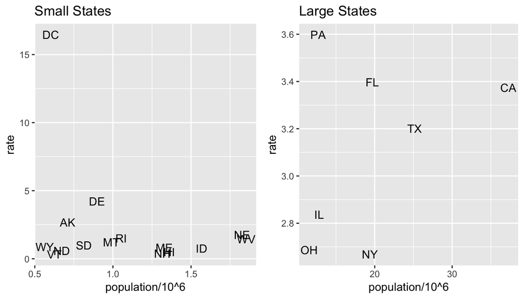

```r
grid.arrange(p1, p2, ncol = 2)
```